# IOT Network Intrusion Detection Analysis

Q3 : Which combinations of dimensions is responsible for the different type of attack ?

This project aims to analyze and visualize network attacks within Internet of Things (IoT) environments using the RT-IoT 2022 dataset, which includes network traffic data from both normal and malicious activities across various IoT devices. By examining metrics like protocol usage, bandwidth, payload size, and flow characteristics, the study seeks to identify distinctive patterns associated with different types of attacks. These insights will contribute to developing more effective intrusion detection strategies, enhancing cybersecurity within IoT systems. Ethical considerations are minimal, as the dataset excludes sensitive information.

Author

Affiliation

Team ViZZards

School of Information, University of Arizona

## Libraries and Setup

```r
if (!require(pacman))
  install.packages("pacman")

pacman::p_load(
  # Core data manipulation and visualization
  tidyverse,
  glue,
  scales,
  ggplot2,
  grid,
  readr,
  corrplot,
  dplyr,


  # Additional visualization packages
  viridis,
  RColorBrewer,

  # Data manipulation
  data.table,
  tibble,

  # Additional utilities
  stringr,
  lubridate,
  forcats,
  purrr,
  tidyr,
  magrittr
)
```

## Dataset

```r
data <- read_csv("data/data.csv")

# Assign distinct colors to each attack type
unique_attacks <- unique(data$Attack_type)
attack_colors <- hue_pal()(length(unique_attacks))

# Filter dataset to exclude NMAP attacks
filtered_data <- data %>%
  filter(!grepl("NMAP", Attack_type, ignore.case = TRUE))
```

## Bandwidth Analysis

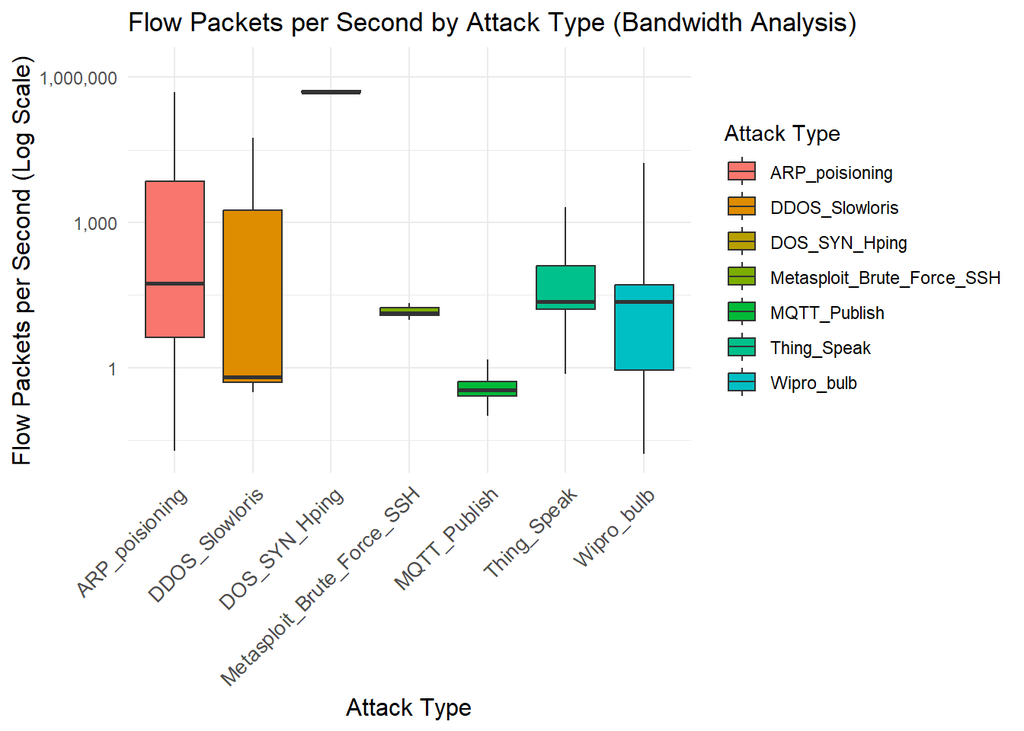

```r
# Remove extreme outliers (top 1%)
bandwidth_data <- filtered_data %>%
  filter(flow_pkts_per_sec < quantile(flow_pkts_per_sec,
                                      0.99,
                                      na.rm = TRUE))

# Create the boxplot with improved scaling and layout
ggplot(bandwidth_data, aes(x = Attack_type,
                           y = flow_pkts_per_sec,
                           fill = Attack_type)) +
  geom_boxplot(outlier.shape = NA) + # Suppress individual outliers
  scale_fill_manual(values = attack_colors) + # Custom colors for attack types
  theme_minimal() +
  theme(
    axis.text.x = element_text(angle = 45, hjust = 1, size = 10), # Adjust x-axis
    axis.title = element_text(size = 12),
    legend.position = "right"
  ) +
  scale_y_log10(labels = scales::comma) + # Apply log10 scale
  labs(
    title = "Flow Packets per Second by Attack Type (Bandwidth Analysis)",
    x = "Attack Type",
    y = "Flow Packets per Second (Log Scale)",
    fill = "Attack Type"
  )
```

### Analysis :-

**Variable Interaction:**

## Inter-Arrival Time Analysis

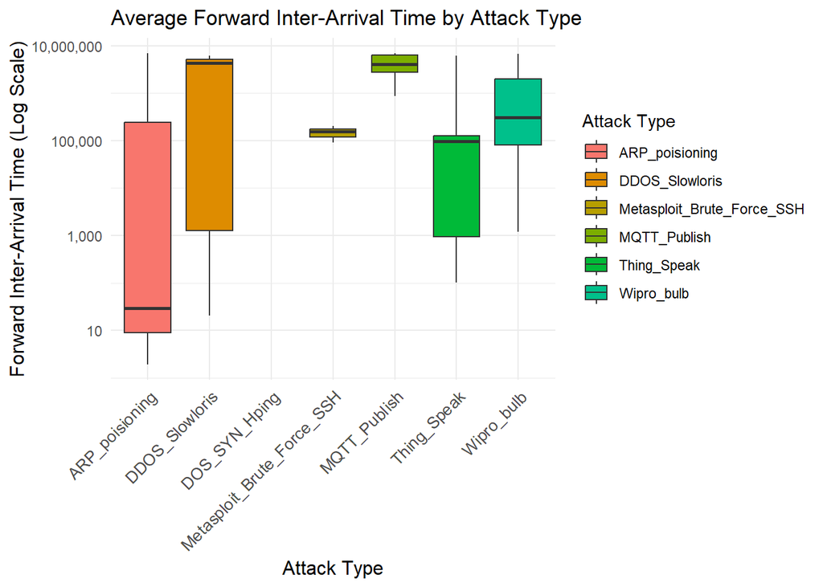

```r
# Remove extreme outliers (top 1%)
iat_data <- filtered_data %>%
  filter(fwd_iat.avg < quantile(fwd_iat.avg, 0.99, na.rm = TRUE))

# Create the boxplot with improved formatting and log scale
ggplot(iat_data, aes(x = Attack_type, y = fwd_iat.avg, fill = Attack_type)) +
  geom_boxplot(outlier.shape = NA) + # Suppress individual outliers
  scale_fill_manual(values = attack_colors) + # Custom colors for attack types
  theme_minimal() +
  theme(
    axis.text.x = element_text(angle = 45, hjust = 1, size = 10),
    axis.title = element_text(size = 12),
    legend.position = "right"
  ) +
  scale_y_log10(labels = scales::comma) + # Apply log10 scale for y-axis
  labs(
    title = "Average Forward Inter-Arrival Time by Attack Type",
    x = "Attack Type",
    y = "Forward Inter-Arrival Time (Log Scale)",
    fill = "Attack Type"
  )
```

### Analysis :-

**Variable Interaction:**

fwd_iat.avg (average inter-arrival time) and its distribution differ across attack types.

DDOS_Slowloris shows high inter-arrival times, reflecting deliberate delays.

MQTT_Publish exhibits tightly packed inter-arrival times, indicating efficient payload delivery.

**Inference:**

Slowloris attacks exploit resource-holding behaviors with prolonged intervals, interacting with server timeout mechanisms.

## Payload Behavior Analysis

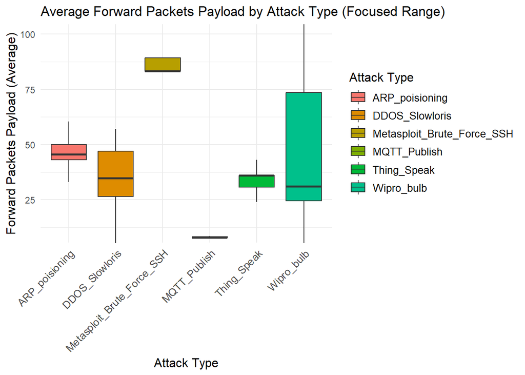

```r
# Remove extreme outliers (top 1%)
payload_data <- filtered_data %>%
  filter(fwd_pkts_payload.avg < quantile(fwd_pkts_payload.avg,
                                         0.99,
                                         na.rm = TRUE))

# Create the boxplot with focused y-axis range
ggplot(payload_data, aes(x = Attack_type,
                         y = fwd_pkts_payload.avg,
                         fill = Attack_type)) +
  geom_boxplot(outlier.shape = NA) + # Suppress individual outliers
  scale_fill_manual(values = attack_colors) + # Custom colors for attack types
  theme_minimal() +
  theme(
    axis.text.x = element_text(angle = 45,
                               hjust = 1,
                               size = 10),
    axis.title = element_text(size = 12),
    legend.position = "right",
    legend.title = element_text(size = 12),
    legend.text = element_text(size = 10)
  ) +
  coord_cartesian(ylim = c(10, 100)) + # Focus on y-axis range 10 to 100
  labs(
    title = "Average Forward Packets Payload by Attack Type (Focused Range)",
    x = "Attack Type",
    y = "Forward Packets Payload (Average)",
    fill = "Attack Type"
  )
```

### Analysis:-

**Variable Interaction:**

Variables like fwd_pkts_payload.avg and fwd_pkts_payload.max interact to characterize payload distribution.

Wipro_bulb shows a wide payload range, indicating varied message sizes, while DDOS_Slowloris clusters at smaller payloads.

**Inference:**

Larger payload ranges indicate dynamic and adaptable attacks (e.g., Wipro_bulb), while smaller ranges (e.g., Slowloris) rely on consistent patterns to exhaust resources.

Payload variability can be a signature of attack intent (e.g., reconnaissance vs. volumetric).

## Heatmaps for Each Attack Type

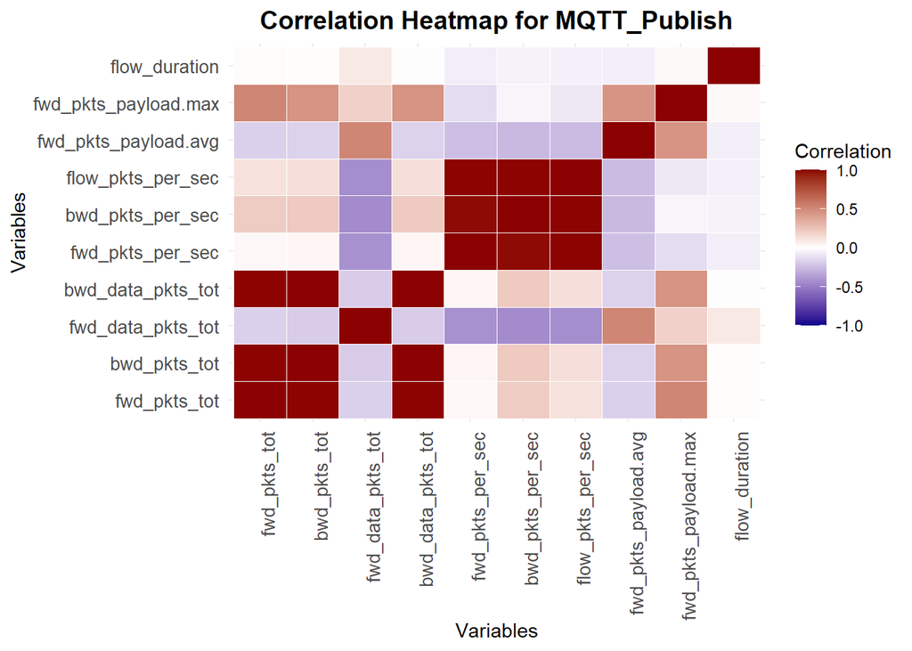

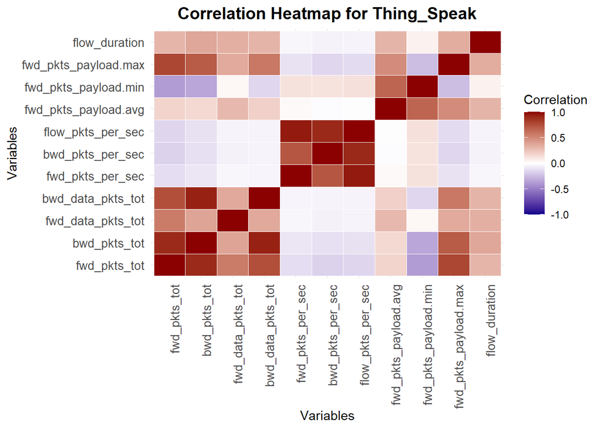

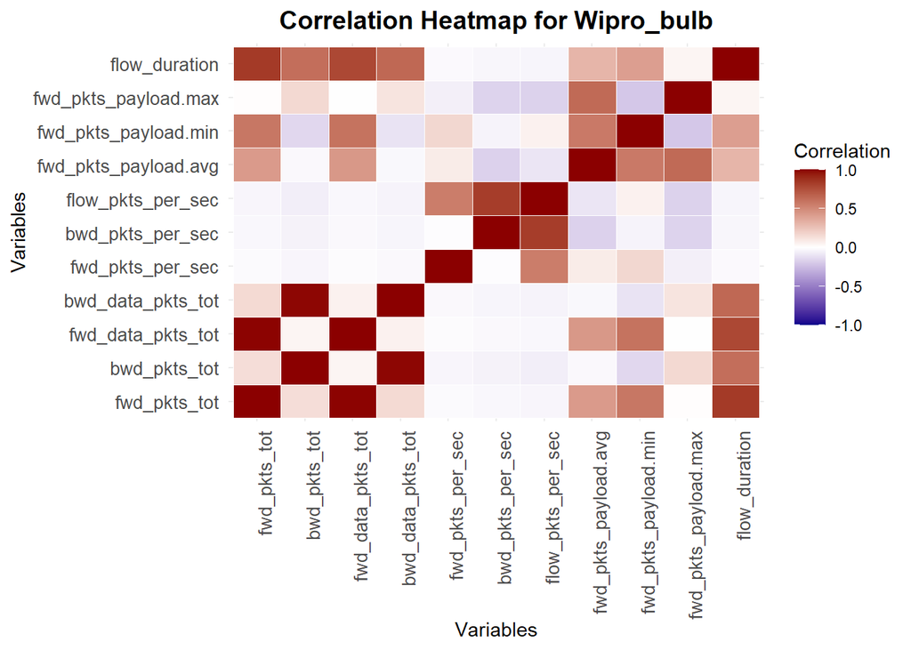

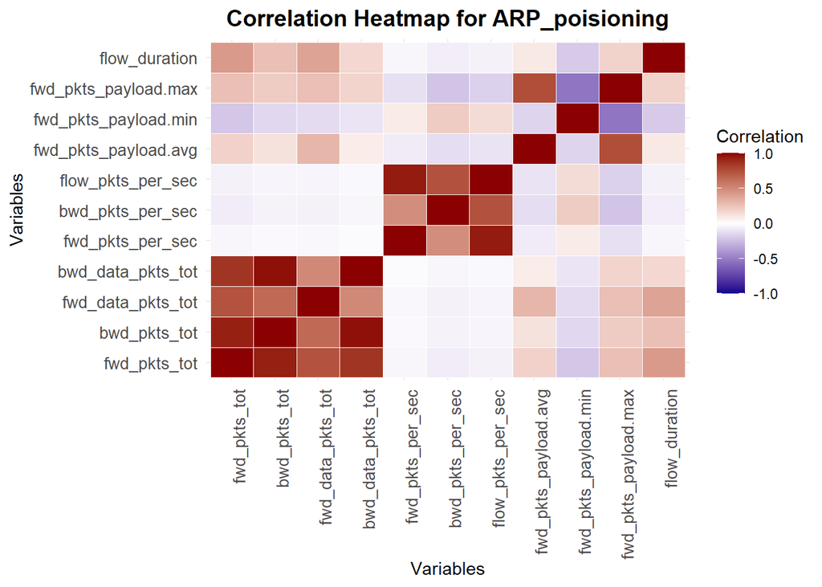

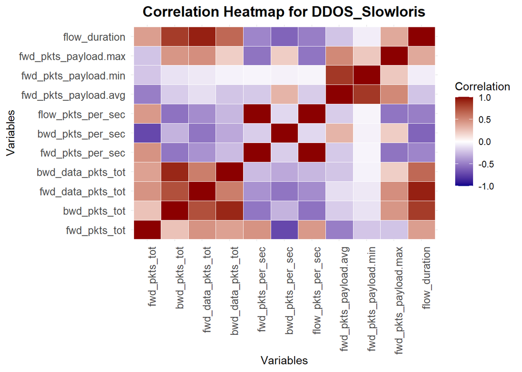

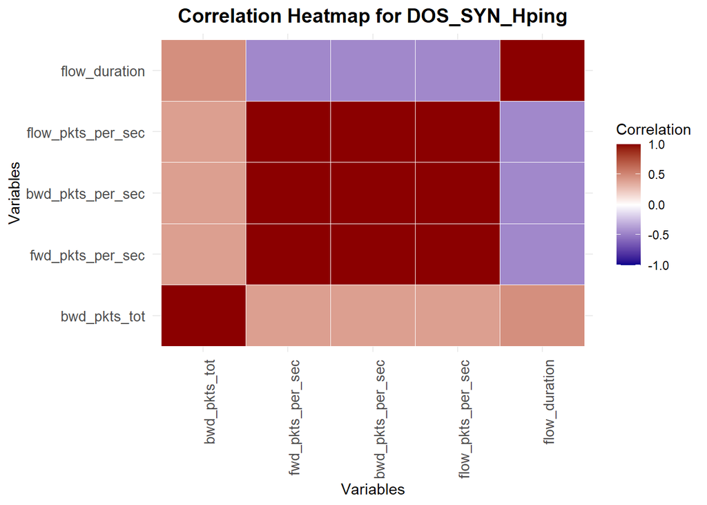

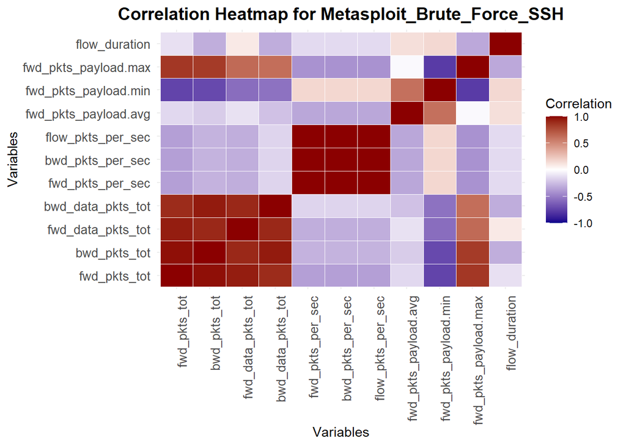

```r
# Select only bandwidth, packet size, and flow-related variables
heatmap_vars <- c(
  "fwd_pkts_tot", "bwd_pkts_tot", "fwd_data_pkts_tot", "bwd_data_pkts_tot",
  "fwd_pkts_per_sec", "bwd_pkts_per_sec", "flow_pkts_per_sec",
  "fwd_pkts_payload.avg", "fwd_pkts_payload.min", "fwd_pkts_payload.max",
  "flow_duration"
)

# Loop through each unique attack type
for (attack in unique(filtered_data$Attack_type)) {
  # Filter data for the specific attack type
  attack_data <- filtered_data %>% filter(Attack_type == attack)

  # Ensure there are enough observations to compute correlations
  if (nrow(attack_data) < 5) next

  # Subset only the relevant columns present in attack_data
  relevant_vars <- intersect(heatmap_vars, names(attack_data))

  # Remove variables with constant values or too many missing values
  valid_vars <- sapply(attack_data[, relevant_vars, drop = FALSE], function(col) {
    var(col, na.rm = TRUE) > 0 & sum(is.na(col)) / length(col) < 0.5
  })

  # Subset the attack_data to valid variables only
  attack_data <- attack_data[, names(valid_vars)[valid_vars], drop = FALSE]

  # Calculate correlation matrix, excluding NA values
  if (ncol(attack_data) > 1) {
    corr_matrix <- cor(attack_data, use = "pairwise.complete.obs")

    # Replace NA correlations with 0 (optional)
    corr_matrix[is.na(corr_matrix)] <- 0

    # Create the heatmap
    heatmap <- ggplot(melt(corr_matrix), aes(Var1, Var2, fill = value)) +
      geom_tile(color = "white") +
      scale_fill_gradient2(
        low = "darkblue", mid = "white", high = "darkred", midpoint = 0,
        limit = c(-1, 1), name = "Correlation"
      ) +
      labs(
        title = paste("Correlation Heatmap for", attack),
        x = "Variables",
        y = "Variables"
      ) +
      theme_minimal() +
      theme(
        axis.text.x = element_text(angle = 90, hjust = 1, size = 10),
        axis.text.y = element_text(size = 10),
        plot.title = element_text(hjust = 0.5, size = 14, face = "bold")
      )

    # Print the heatmap
    print(heatmap)
  }
}
```

### Analysis :-

**1. ARP_Poisoning**

**Inference:** ARP poisoning exploits bidirectional communication, emphasizing the importance of packet symmetry in its success.

**2. DDOS_Slowloris**

**Inference:** Interaction between low bandwidth, small payloads, and long durations indicates a resource-depleting strategy without significant data transfer.

**3. DOS_SYN_Hping**

**Inference:** This attack relies on large volumes of forward packets to overwhelm servers, showing a direct relationship between packet frequency and attack intensity.

**4. Metasploit_Brute_Force_SSH**

**Inference:** The attack uses sustained sessions with consistent payloads, emphasizing authentication cracking through repetitive probes.

**5. MQTT_Publish**

**Inference:** MQTT_Publish exploits efficiency in payload delivery, highlighting its IoT application focus.

**6. Thing_Speak**

**Inference:** Thing_Speak operates with minimal but consistent bidirectional traffic, leveraging IoT protocols for covert data exchanges.

**7. Wipro_Bulb**

**Inference:** The attack utilizes high variability in payload and packet flow, reflecting erratic patterns aimed at dynamic IoT environments.

## Synthesis of Variable Interactions Across Attack Types:-

**2. Temporal Manipulation:**

fwd_iat.avg is a defining characteristic for attacks like Slowloris, which exploit high inter-arrival times to hold server resources.

**3. Payload Dynamics:**

Variability in fwd_pkts_payload.max reflects attack adaptability. Static payloads indicate systematic attacks (e.g., Metasploit_Brute_Force_SSH), while dynamic payloads (e.g., Wipro_bulb) signify flexible, IoT-specific threats.

**4. Bidirectional Traffic:**

Correlations between bwd_pkts_tot and fwd_pkts_tot highlight the reliance on bidirectional traffic for attacks like ARP_poisoning, which exploit network routing vulnerabilities.

**5.Attack Fingerprinting:**

Each attack type displays unique interaction patterns among variables, creating distinct signatures. These can inform the development of targeted anomaly detection systems.

## Conclusion

The interaction of variables such as bandwidth, payload, and inter-arrival time during an attack provides critical insights into the mechanisms and intent of various attack types on IoT devices. High bandwidth and rapid packet flows signify volumetric attacks, while prolonged inter-arrival times suggest resource-exhausting tactics. Variable correlations, like those observed in payload size and flow rates, underline the adaptability and stealth of IoT-targeted attacks.

**Significance: Understanding these interactions allows for:**

**Attack Fingerprinting:** Identifying unique behavioral signatures for each attack.

**Anomaly Detection:** Designing systems that leverage these patterns for early detection.

**IoT-Specific Defenses:** Developing tailored security protocols for IoT environments, accounting for their unique traffic and payload characteristics.

**Limitation:** Hence the actual source and destination wasnt included in the dataset the Identification of source of attack cannot be determined which undermines anamoly detection.

This analysis provides a foundation for developing advanced, adaptive intrusion detection systems (IDS) tailored to IoT environments.